# Module 11. Diagnostics and troubleshooting

Slides

# Why diagnostics are different here

## Each assumption matters for some conclusions more than others

| Assumption | Main check | Matters for the treatment effect? |
| --- | --- | --- |
| Mean model | Residuals vs time, fitted; observed vs fitted means | Yes: bias |
| Covariance model | Cholesky-scaled residuals; implied vs observed covariance | SEs; MAR validity |
| Normal residuals | Q–Q plot | Little (prediction intervals) |
| Normal random effects | BLUP Q–Q plot (with care) | Little (individual predictions) |
| No dominant participant | Leave-one-participant-out | Fragility |
| GLMM distribution | DHARMa: dispersion, zeros | SEs, possible bias |

## Decide in advance what each answer would make you do

- A check is useful only if you know what you would do with each result
- Write the responses in the analysis plan (Module 12) and the analysis log
- Diagnostic work blind to arm protects against choosing the “best” model

# Residuals for the linear mixed model

## Two residuals: distance from the arm mean, distance from your own line

$$\hat r_{ij} = y_{ij} - \mathbf{x}_{ij}^\top\hat{\boldsymbol\beta}\ \ \text{(marginal)}
\qquad
\hat e_{ij} = y_{ij} - \mathbf{x}_{ij}^\top\hat{\boldsymbol\beta} - \hat b_{0i} - \hat b_{1i}t_{ij}\ \ \text{(conditional)}$$

- Marginal: checks mean and covariance together; correlated within participant
- Conditional: checks residual error; shrunk and negatively correlated within participant

```r
fitted(m_pri)                      # X beta + Z b
predict(m_pri, re.form = NA)       # X beta only
resid(m_pri, scaled = TRUE)        # standardised conditional residual
```

## The WALK primary model passes the standard checks

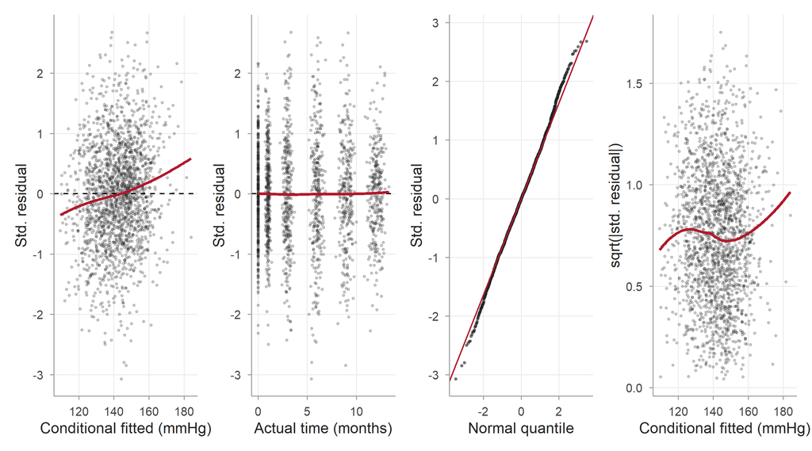

Range -3.07 to 2.68; 2.3% beyond ±2 (fewer than 5%, because of shrinkage).

## Marginal residuals need scaling before they can be read

Cholesky scaling: $\hat V_i = L_iL_i^\top$, $\ \hat{\mathbf{r}}^*_i = L_i^{-1}\hat{\mathbf{r}}_i$, approximately independent $N(0,1)$ if the model is right.

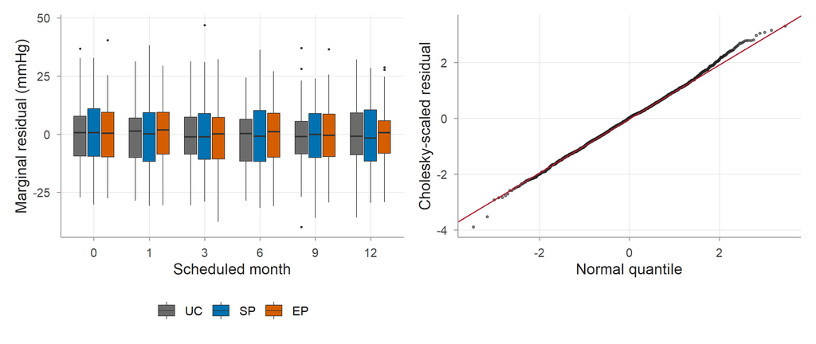

## Conditional residuals cannot detect serial correlation; scaled marginal residuals can

| Lag-1 correlation within participant | Value |
| --- | --- |
| Conditional residuals | -0.21 |
| Cholesky-scaled marginal residuals | 0.06 |

- Conditional: negative by construction (the random line is fitted through the points)
- Scaled marginal: small positive value, a trace of the serial correlation in the simulated truth
- Response: a planned sensitivity analysis with exponential correlation (Module 5), not a silent change of model

## Try it

Workbook 11, **Exercise G1**: conditional and marginal residuals for the linear-time WALK model.

# Influential participants

## Leave out one participant at a time and watch the estimate that matters

$$\text{DFBETA}_i = \hat\delta - \hat\delta_{(-i)},\qquad
D_i = \frac{(\hat{\boldsymbol\beta} - \hat{\boldsymbol\beta}_{(-i)})^\top \widehat{\text{Var}}(\hat{\boldsymbol\beta})^{-1}(\hat{\boldsymbol\beta} - \hat{\boldsymbol\beta}_{(-i)})}{p}$$

```r
m_g <- lmer(sbp ~ visit_f * arm + (1 + month | id),
            data = walk[walk$id != g, ], control = lmer_ctrl,
            start = getME(m_pri, "theta"))   # warm start
fixef(m_g)["visit_f12:armEP"]               # = EP - UC change at month 12
```

## No WALK participant moves the primary estimate by more than a fifth of a standard error

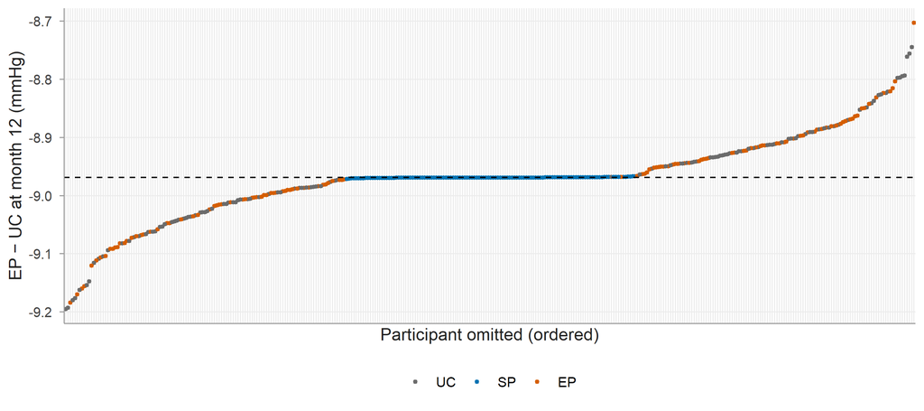

Full data -8.97 (SE 1.44); range -9.2 to -8.7; largest shift 19% of an SE.

## Try it

Workbook 11, **Exercise G2**: find the most influential participants and look at their trajectories.

# Random-effects assumptions

## BLUPs are shrunk, so their plots are weak evidence

$$\hat b_{0i} = \lambda_i(\bar y_i - \hat\mu),\qquad \lambda_i = \frac{\tau_0^2}{\tau_0^2 + \sigma^2/n_i}$$

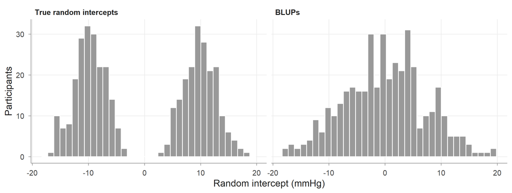

## Non-normal random effects barely affect the fixed effects

| Random effects | Bias | Empirical SE | Mean model SE | 95% CI coverage |
| --- | --- | --- | --- | --- |
| bimodal | 0.012 | 0.145 | 0.136 | 0.927 |
| normal | 0.000 | 0.135 | 0.136 | 0.950 |
| skewed | 0.009 | 0.131 | 0.137 | 0.973 |

300 simulated trials per row, 60 per arm, true difference in slopes −0.5 mmHg/month. Monte Carlo SE of coverage about 0.015.

## Try it

Workbook 11, **Exercise G3**: shrinkage factors and BLUP spread in WALK.

# GLMMs and GEE

## Simulated residuals put every model on the same uniform scale

$$u_k = \Pr\nolimits_{\text{sim}}(y_k^{(s)} < y_k) + V_k \Pr\nolimits_{\text{sim}}(y_k^{(s)} = y_k),\qquad u_k \sim \text{U}(0,1) \text{ if the model is right}$$

```r
m_pois <- glmmTMB(migraine_days ~ arm * post + offset(log(days)) + (1 | id),
                  family = poisson, data = diary)
sim_pois <- simulateResiduals(m_pois, n = 1000, seed = 1104)
plot(sim_pois); testDispersion(sim_pois); testZeroInflation(sim_pois)
```

## The Poisson model for DIARY is overdispersed; the negative binomial shows no clear misfit

| Model | Dispersion | Zero ratio | SE of armActive:post |
| --- | --- | --- | --- |
| Poisson GLMM | 1.512 | 1.593 | 0.08 |
| Negative binomial GLMM | 1.150 | 1.056 | 0.12 |

The “excess zeros” of the Poisson model disappear once overdispersion is modelled: no zero-inflation model is needed.

## Participant-level checks need unconditional simulation

- DHARMa 0.5.0 simulates **conditional** on the fitted random effects by default
- In 20 datasets from a *correct* logistic random-intercept model, the participant-level dispersion test rejected 100% of the time (conditional) and 0% (unconditional)

```r
s_u <- simulateResiduals(m_clear, n = 1000, simulateREs = "unconditional")
testDispersion(recalculateResiduals(s_u, group = clear$id))
```

## For GEE, check the mean model against observed proportions

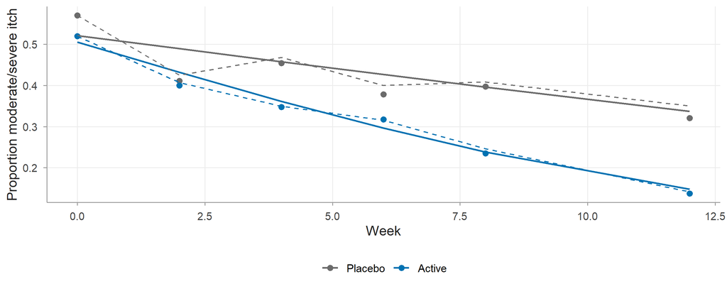

QIC: linear 1345.4, categorical week 1351.9 (lower is better).

## Try it

Workbook 11, **Exercise G4**: DHARMa for DIARY, including a participant-level check.

# Convergence, singular fits and separation

## A convergence warning is an invitation to investigate

1. Read the warning and look at the estimates (zero variances, ±1 correlations, huge coefficients)
2. Rescale time and covariates
3. Check the gradient; compare optimisers with `allFit()`
4. If singular, simplify in a pre-specified order
5. Binary GLMMs: compare Laplace with adaptive quadrature
6. Separation: penalised likelihood, and report the sparse table

## Time in days and age in years: a warning that is a scaling artefact

- Badly scaled fit: “Model is nearly unidentifiable: very large eigenvalue. Rescale variables?”
- Random-slope SD 0.017 mmHg/day against intercept SD 12.4 mmHg
- After rescaling: no warning, and the EP slope difference is identical: -0.723 vs -0.723 mmHg/month

## `allFit()`: if all optimisers agree, the warning is a false alarm

|  | logLik | EP - UC | warning |
| --- | --- | --- | --- |
| bobyqa | -6624 | -8.969 | FALSE |
| Nelder_Mead | -6624 | -8.969 | FALSE |
| nlminbwrap | -6624 | -8.969 | FALSE |
| nloptwrap.NLOPT_LN_NELDERMEAD | -6624 | -8.969 | TRUE |
| nloptwrap.NLOPT_LN_BOBYQA | -6624 | -8.969 | FALSE |

## Eight clinics cannot support a random slope: singular fit

```
#>  Groups   Name        Std.Dev. Corr
#>  id       (Intercept) 11.851
#>           month        0.524   -0.17
#>  clinic   (Intercept)  3.755
#>           month        0.139   -1.00
#>  Residual              5.622
```

`isSingular()` is TRUE: the clinic intercept-slope correlation is at −1. Simplify to `(1 | clinic)`.

## Separation: a coefficient of −16 with SE 1,388 is not an estimate

| Method | Estimate | SE |
| --- | --- | --- |
| glm (ML) | -16.27 | 1388.34 |
| Firth penalised likelihood | -1.70 | 1.72 |
| glmmTMB, normal(0, 2.5) prior | -1.86 | 1.66 |

No events in 60 post-baseline active-arm visits: report this table too (Heinze and Schemper 2002).

## Binary GLMMs: Laplace underestimates a large random-intercept SD

| nAGQ | week:armActive | Random-intercept SD |
| --- | --- | --- |
| 1 | -0.127 | 1.668 |
| 5 | -0.130 | 1.749 |
| 10 | -0.130 | 1.760 |
| 25 | -0.130 | 1.760 |

## Try it

Workbook 11, **Exercise G5**: rescaling, `allFit()` and a separation table.

# Responding to problems and recording decisions

## Fix the problem the diagnostic found, not a different one

| Problem | Principled response | Not this |
| --- | --- | --- |
| Curvature over time | More flexible time, all arms | Terms only where they help the effect |
| Serial correlation | Add a structure; compare SEs | Ignore it because the SE is small |
| Influential participant | Verify data; sensitivity analysis | Drop from the primary analysis |
| Overdispersed counts | Negative binomial | Try models until p < 0.05 |
| Convergence warning | Rescale, `allFit()`, planned simplification | Keep the fit with the best effect |

## An analysis log makes every decision traceable

| Field | Entry |
| --- | --- |
| Observed | “Nearly unidentifiable” warning, time in days |
| Status | Data-driven, blind to comparison |
| Decision | Time in months, age per 10 years; `allFit()` for the primary model |
| Effect on estimates | None: EP slope difference -0.723 mmHg/month in both fits |

Template: `admin/templates/analysis_log_template.md`

## Try it

Workbook 11, **Exercise G6**: write two analysis-log entries; then the independent exercises.

## Summary

- Conditional residuals check the within-participant model; Cholesky-scaled marginal residuals check mean and covariance
- Influence is measured by leaving out participants and watching the reported estimate
- BLUP plots are weak evidence; fixed effects are robust to non-normal random effects
- DHARMa puts GLMMs on a uniform scale; use unconditional simulation for participant-level checks
- Warnings: rescale, compare optimisers, simplify as planned, penalise under separation
- Decide responses in advance and log every decision

Heinze, Georg, and Michael Schemper. 2002. ‘A Solution to the Problem of Separation in Logistic Regression’. *Statistics in Medicine* 21 (16): 2409–19. https://doi.org/10.1002/sim.1047.